# Al Fakhbir - Gamma Persei

## Descrizione

Si tratta di una binaria le cui componenti sono di classe differente ma luminosità molto simile. Le luminosità riportate da SkySafari sono di 3.6 e 3.8

Sembrerebbe essere una binaria ad eclisse per cui potrebbe essere interessante studiare il cambiamento dello spettro durante l'eclissi. Purtroppo però il periodo indicato dal database AAVSO è di 14.6 anni. Da un articolo citato da AAVSO si capisce inoltre che l'orbita è fortemente ellittica e le eclissi primaria e secondaria avvengono a soltanto un anno di distanza una dall'altra. L'eclissi primaria studiata nell'articolo è del settembre 1990 per cui mi aspetto che ne sia avvenuta un'altra a fine 2020 con la secondaria nel 2021 e che la prossima si verifichi a inizio 2035.

[Riconoscimento righe](https://docs.google.com/spreadsheets/d/1MF80x46pgjfDqt47KEIjhnmBUFaPf7Tv_BDkRVyeUZ8/edit?usp=drive_link)

## Classificazione

A un primo sguardo lo spettro è di difficile interpretazione: presenta sia forti righe della serie di Balmer (ad es. la riga K del Ca II è molto più debole delle righe di Balmer adiacenti) come se fosse una A o una early F, sia forti righe del ferro come nelle late F e nelle G.

[Simbad](https://simbad.cds.unistra.fr/simbad/sim-basic?Ident=gamma+per&submit=SIMBAD+search) la classifica come G9III+A2-III

## Osservazioni

- 27/04/2024
- 28/04/2024
- 24/04/2025

## Confronto tra le osservazioni del 27/04/2024 e 28/04/2024

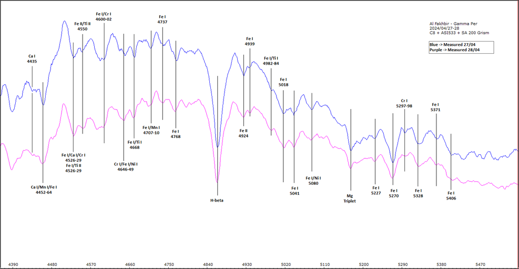